# Linking satellite environmental exposures to a child cohort

A reproducible exposure database for Freiburg im Breisgau, 2021–2024

Jay Damani

29 October 2026

# 1 Summary

This report documents a working exposure-linkage pipeline for Freiburg im Breisgau. Satellite land surface temperature, satellite vegetation, classified land cover and terrain are processed into a hexagonal grid, quality-screened, gap-filled with a validated method, and linked to a simulated cohort of 500 children over exposure windows of 7, 30 and 365 days before each child’s examination date. The output is a single DuckDB database with full provenance on every value, 19 automated integrity tests, and a demonstrated incremental update procedure.

The cohort is simulated; **all environmental data are real**. Code, tests and pinned package versions: github.com/damanijay/Freiburg-exposure-linkage. Pipeline scripts are in `R/`, numbered in run order; integrity tests are in `tests/`.

Headline results

| Finding | Result |
| --- | --- |
| Satellite gaps are seasonal and spatially clustered | 14.4% of hexagon-weeks missing; 46% in October, 0.9% in August; 26.5% missing in populated hexagons vs 22.9% elsewhere |
| Ignoring gaps biases annual exposure | Annual exposure overestimated by 1.43 °C on average, in the same direction for nearly every child |
| Gap-filling method selected on pre-specified rule | Climatology-plus-anomaly, cold-season RMSE 1.66 °C on withheld pixels |
| Satellite tracks ground-measured weather | Deseasonalised correlation with DWD station Freiburg r = 0.82 |
| Elevation confounds the green–heat relationship | Apparent cooling per 10 pp green falls 45% after adjustment (−0.74 to −0.40 °C) |
| Exposure window determines what is measured | Exam month explains 92% of 7-day exposure; location explains 63% of 365-day exposure |
| Lower socioeconomic position, hotter and less green | −0.22 °C annual LST and +3.6 pp green per 1 SD higher SES |

# 2 Background and objective

Environmental epidemiology in child cohorts needs exposure values attached to individual participants at individual dates. The practical obstacle is rarely the statistical model; it is that satellite records are incomplete, that the incompleteness is not random, and that exposure must be defined over a window that matches the hypothesised mechanism.

The objective here was to build the full chain end to end for one city, document every decision, and show that the result can be maintained when new data arrive. Freiburg was chosen because it spans 195 m on the Rhine valley floor to 1,283 m in the Black Forest within a single municipality, which makes terrain confounding visible rather than hypothetical.

## 2.1 Data sources

Input data

| Source | Variable | Use |
| --- | --- | --- |
| MODIS MOD11A2 v061 | Land surface temperature, 8-day composite, 1 km | Heat exposure 2021–2024 |
| Sentinel-2 L2A | NDVI, summer median, 10 m | Vegetation greenness |
| ESA WorldCover 2021 | Land cover, 10 m | Green, built-up, cropland, water shares |
| OpenStreetMap | Parks, forest, water features | Independent green comparison; park access |
| Copernicus DEM GLO-30 | Elevation, 30 m | Terrain confounder |
| DWD station 01443 | Daily air temperature (Tmax, Tmean) | External validation |
| OSM administrative boundary | Municipal boundary | Study area definition |

## 2.2 Analytical grid

The city (152.9 km²) was tiled with 204 hexagons of 1 km². Hexagons are preferred to squares because every neighbour shares an edge at equal centroid distance, which avoids the diagonal-neighbour ambiguity of a square lattice. Edge hexagons are retained with an `inside_frac` weight; land-cover shares are computed over the within-city portion only. Applying this weighting changed the citywide built-up share from 13.8% to 16.4% — the unweighted figure had diluted dense edge hexagons with area outside the municipality.

# 3 Methods

## 3.1 Quality screening of satellite temperature

MODIS pixels were accepted only where the QC bitfield indicated good quality or an LST error below 2 K (mandatory QA 0, or 1 with error flag ≤ 1). Pixels failing this were set to missing rather than retained with a warning flag, on the basis that a flagged value propagates silently into a weekly mean.

A hexagon-week was treated as observed only if **at least 50% of the hexagon area** had valid pixels. Without this rule, a hexagon mean could be computed from a single clear corner and would not represent the hexagon. The threshold was fixed before results were examined.

## 3.2 Gap diagnosis

Exposure-window completeness before gap-filling

| Window | No data at all | Coverage below 50% | Worst quarter |
| --- | --- | --- | --- |
| 7 days | 50 children (10.0%) | 19.6% | Q4: 34.9% |
| 30 days | 3 children (0.6%) | 15.0% | Q4: 37.2% |
| 365 days | 0 | 0% | — |

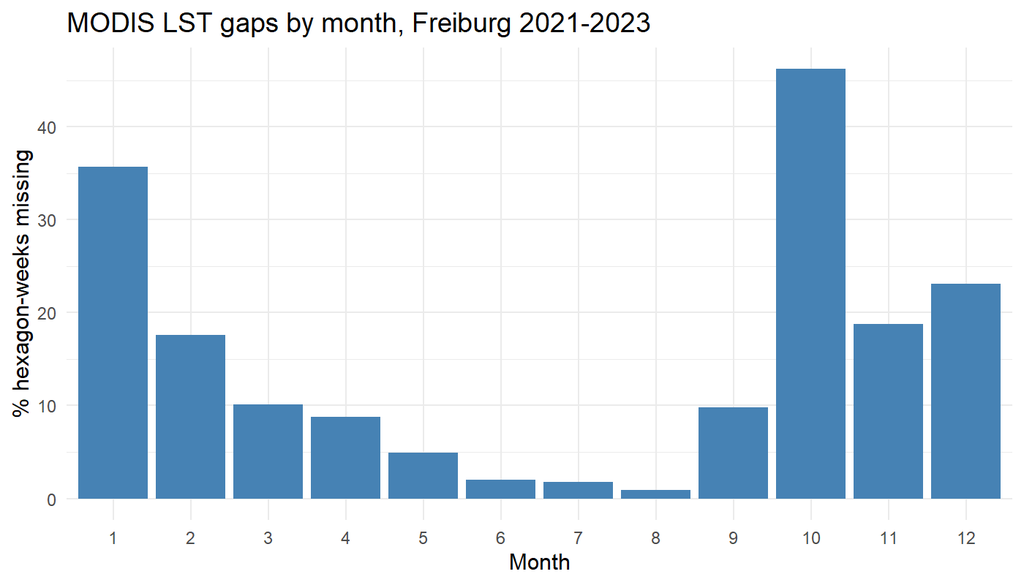

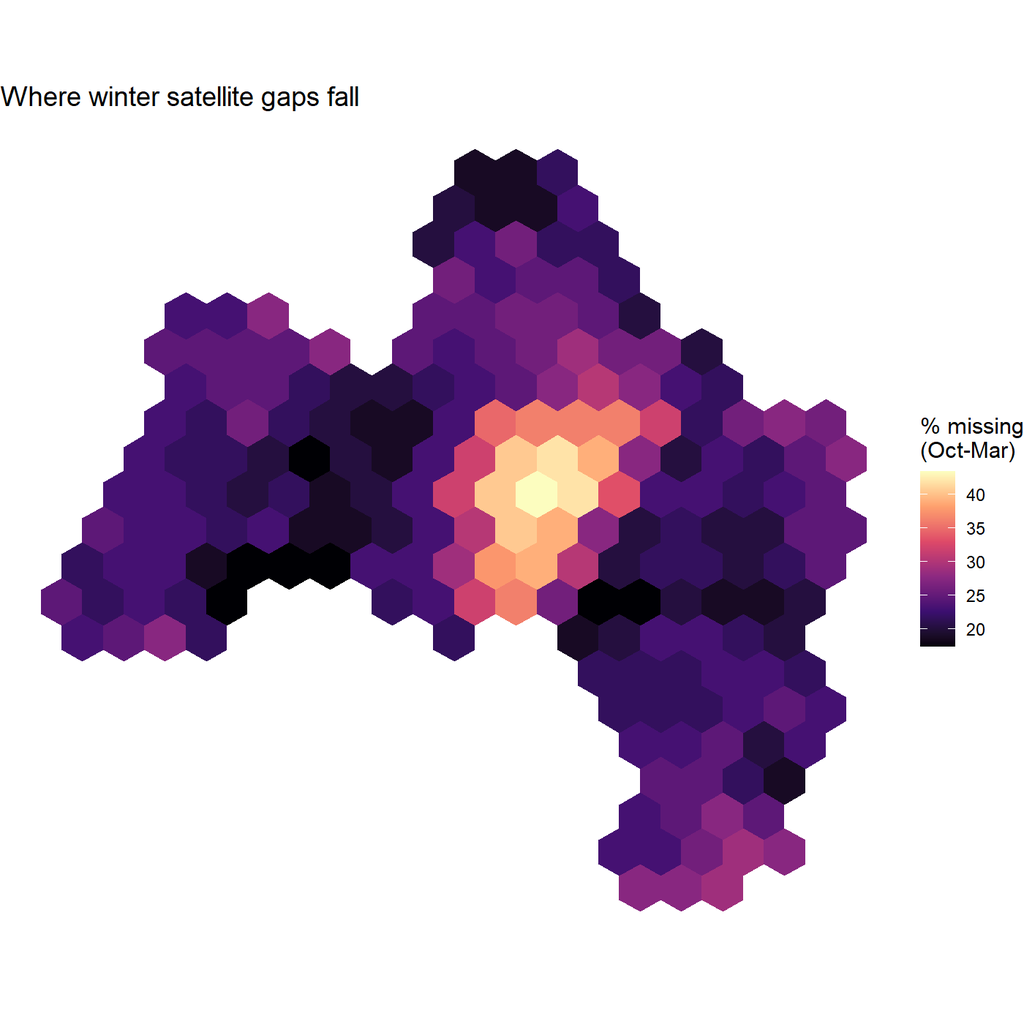

Gaps concentrate between October and February and fall more heavily on the dense city core than on the forested uplands. Hexagons containing cohort children lost 26.5% of cold-season weeks against 22.9% for hexagons without children. Two mechanisms are plausible and cannot be separated with these data: radiation fog pooling on the valley floor, and more frequent QC rejection of mixed urban pixels. Either way the missingness is informative with respect to the study population, which is the reason gap-filling was validated rather than assumed.

## 3.3 Gap-filling: candidate methods and selection

Three methods were compared:

1. **Climatology** — the hexagon’s own mean for that 8-day slot (±1 slot) across all years.
2. **Linear temporal interpolation** — straight line between the nearest observed weeks for that hexagon.
3. **Climatology plus anomaly** — the hexagon’s climatology adjusted by the citywide median anomaly for that week, taken from hexagons that *were* observed; where a whole week is missing, the anomaly is interpolated in time.

Validation withheld 10% of **known** values and compared each method’s reconstruction against the truth, under two withholding schemes: random pixels (scattered cloud) and whole weeks (missing composites). Twenty replicates per scheme. Critically, climatology was recomputed from the withheld matrix in every replicate, so no method had sight of the values it was asked to predict.

**Selection rule, fixed in advance:** lowest cold-season RMSE averaged across both schemes. The cold season is where the real gaps are.

Gap-filling validation (°C), method v1.1

| scheme | season | method | RMSE | MAE | bias |
| --- | --- | --- | --- | --- | --- |
| random_pixels | cold (Oct-Mar) | clim_anomaly | 1.66 | 1.23 | 0.01 |
| random_pixels | cold (Oct-Mar) | climatology | 4.27 | 3.30 | 0.00 |
| random_pixels | cold (Oct-Mar) | linear | 4.47 | 3.16 | 0.13 |
| random_pixels | warm (Apr-Sep) | clim_anomaly | 1.30 | 1.00 | 0.02 |
| random_pixels | warm (Apr-Sep) | linear | 2.99 | 2.31 | 0.02 |
| random_pixels | warm (Apr-Sep) | climatology | 3.31 | 2.68 | 0.08 |
| whole_weeks | cold (Oct-Mar) | climatology | 3.71 | 2.79 | 0.01 |
| whole_weeks | cold (Oct-Mar) | clim_anomaly | 3.91 | 2.75 | -0.32 |
| whole_weeks | cold (Oct-Mar) | linear | 3.97 | 2.67 | 0.03 |
| whole_weeks | warm (Apr-Sep) | linear | 2.61 | 2.05 | -0.22 |
| whole_weeks | warm (Apr-Sep) | clim_anomaly | 2.73 | 2.16 | -0.23 |
| whole_weeks | warm (Apr-Sep) | climatology | 3.19 | 2.58 | -0.67 |

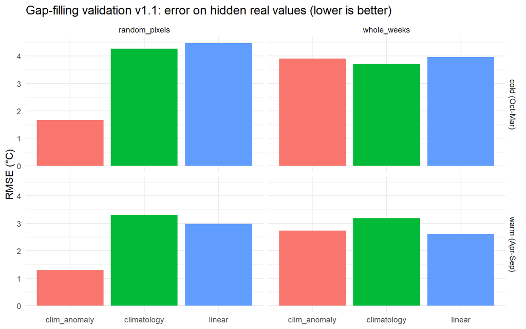

Climatology-plus-anomaly was selected (cold-season mean RMSE 2.79 °C against 3.99 for climatology and 4.22 for linear). Its advantage is large where part of the week was observed — 1.66 °C against 4.27 and 4.47 for random withheld pixels — because the citywide anomaly carries that week’s actual weather. Where an entire composite is missing, no anomaly can be borrowed and all three methods converge near 3.7–4.0 °C. That is the honest ceiling of temporal interpolation without an external meteorological source.

## 3.4 Outlier screening

The anomaly estimator was simultaneously made robust: median rather than mean across hexagons, and trusted only when ≥20% of hexagons were observed that week. This removed the large reconstruction errors previously seen in sparse weeks such as 2 February 2021 (62 of 650 pixels valid).

Dates with most flagged values

| date | hexagons_flagged |
| --- | --- |
| 2021-05-09 | 33 |
| 2022-12-27 | 28 |
| 2021-04-07 | 21 |
| 2023-03-22 | 21 |
| 2021-01-17 | 18 |
| 2021-11-09 | 15 |
| 2023-04-23 | 14 |
| 2023-03-30 | 13 |

## 3.5 Exposure windows

Each composite contributes to a child’s window in proportion to the number of days it overlaps that window; coverage is the fraction of window days with observed data. Because composites tile the calendar exactly, overlap days must sum to the window length, and this is asserted for all 1,500 child-windows.

Heat is assigned at hexagon level (MODIS pixels are ~1 km). Green exposure is measured in a **300 m buffer** around the home, following the WHO accessibility indicator, using 10 m data. Each exposure is resolved at the scale its source supports rather than at a single imposed scale.

# 4 Results

## 4.1 Effect of gap-filling on child exposures

Exposure before and after gap-filling

| Window | Children with no prior value | Mean change (°C) | Mean absolute change (°C) | Largest change (°C) |
| --- | --- | --- | --- | --- |
| 7 days | 50 | -0.01 | 0.40 | 21.80 |
| 30 days | 3 | -0.08 | 0.65 | 5.48 |
| 365 days | 0 | -1.43 | 1.45 | 4.94 |

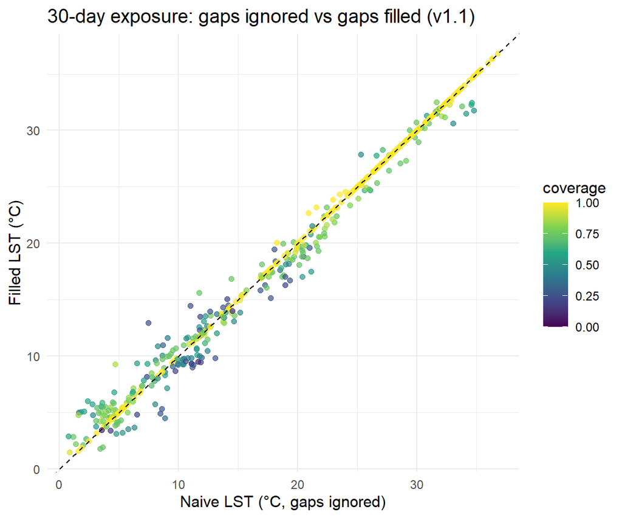

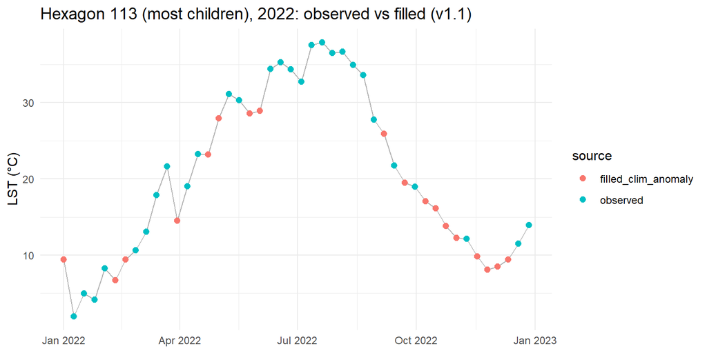

The 365-day row is the substantive finding. The mean change (−1.43 °C) is almost identical in magnitude to the mean absolute change (1.45 °C), meaning nearly every child moved in the same direction. Discarding incomplete weeks removes winter disproportionately, leaving an annual mean weighted toward summer. Because gaps are denser in the built-up core, the bias is spatially structured and would inflate an estimated urban heat island.

For short windows the changes largely cancel (mean −0.01 °C over a mean absolute 0.40 °C) but include individual corrections up to 21.8 °C, where a cloud-contaminated value had dominated a 7-day mean.

## 4.2 External validation against a ground station

DWD station 01443 (Freiburg, 48.0232 °N, 7.8343 °E, 236 m) falls in hexagon 107. Daily records for 2021–2023 are complete (1,095 days, no missing maxima).

Satellite versus ground station, hexagon 107

| Metric | Value |
| --- | --- |
| Raw correlation, LST vs air Tmax | 0.96 |
| Deseasonalised correlation (monthly anomalies) | 0.82 |
| Mean LST − Tmax, cold season (48 weeks) | −1.9 °C |
| Mean LST − Tmax, warm season (62 weeks) | +2.9 °C |
| Residual RMSE, observed weeks (n = 110) | 2.75 °C |
| Residual RMSE, filled weeks (n = 25) | 6.10 °C |
| Residual mean, filled weeks | +0.16 °C |

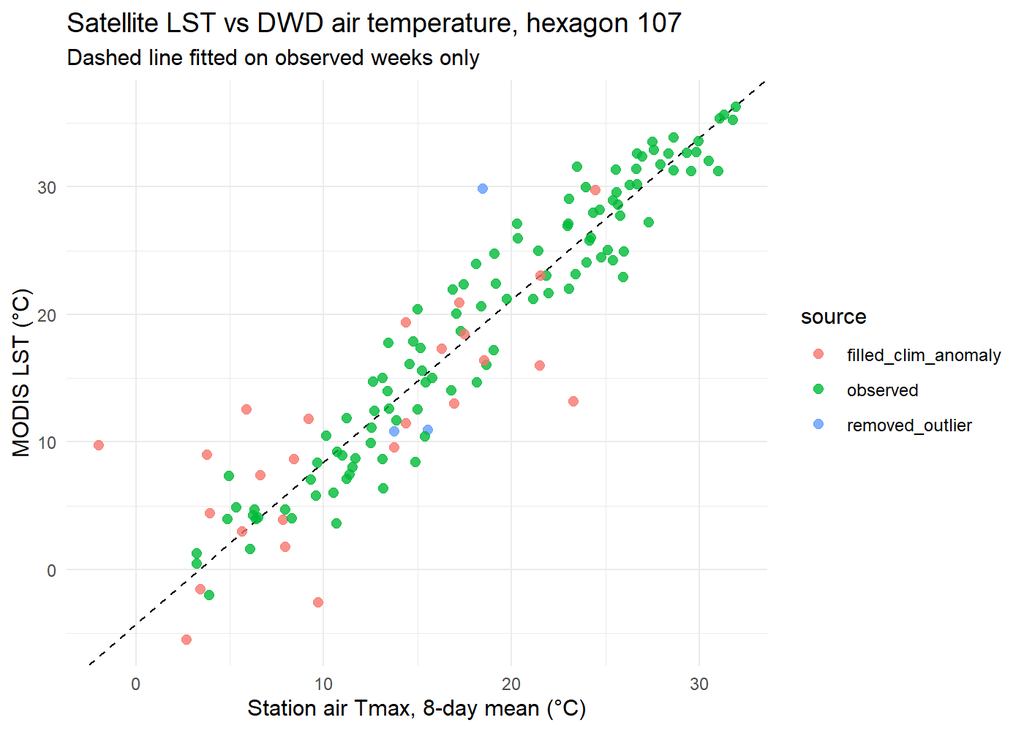

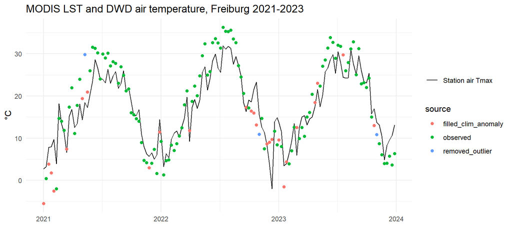

Raw correlation is high (0.96) but largely reflects the annual cycle and is therefore weak evidence. After removing month means, agreement remains strong at **r = 0.82**: the satellite identifies which weeks were unusually warm or cold, not merely which season it was.

The seasonal offsets are physically expected rather than error. In winter the 10:30 surface is **1.9 °C colder** than the afternoon air maximum, because clear nights cool the ground radiatively and the morning surface has not recovered; in summer solar heating puts surfaces **2.9 °C above** air temperature. This also identifies a limitation: MODIS daytime LST is a clear-sky sample, so withheld-clear-week validation is optimistic relative to true gaps, which occur on cloudy days.

Filled weeks show no systematic bias at the station (**+0.16 °C**), agreeing with the −0.32 °C bias measured internally, but their scatter is more than twice that of observed weeks (6.10 against 2.75 °C). Inspection attributes the residual error to entirely missing composites coinciding with unusual weather — late October 2022 reached 23.3 °C and mid-December 2022 was below freezing at the station, neither recoverable from neighbouring weeks.

## 4.3 Terrain as a confounder

Summer LST regressed on green share, with and without elevation

| model | green_per_10pp | elev_per_100m | R2 |
| --- | --- | --- | --- |
| 1: green only | -0.74 | NA | 0.52 |
| 2: green + elevation | -0.40 | -0.71 | 0.77 |

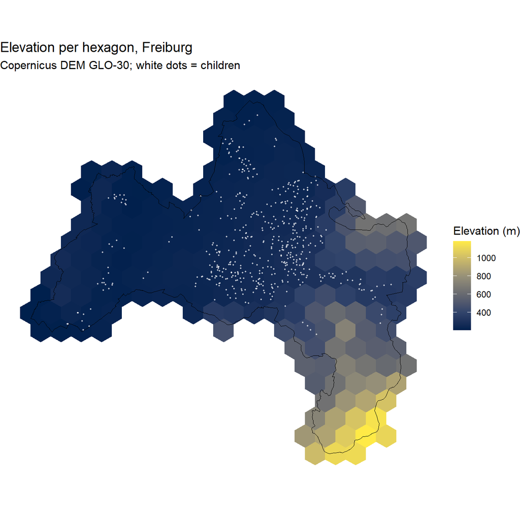

Green share and elevation correlate at r = 0.55 across hexagons: the Black Forest is both green and high. Adjusting for elevation reduces the apparent cooling per 10 percentage points of green from **−0.74 °C to −0.40 °C, a 45% reduction**, while R² rises from 0.52 to 0.77.

The fitted elevation coefficient, **−0.71 °C per 100 m**, is close to the environmental lapse rate of approximately 0.65 °C per 100 m. That the model recovers a known physical quantity it was not given is reassuring about the specification.

One qualification deserves emphasis. Cohort homes span only 199–375 m, because built-up land is confined to the valley floor; the 45% attenuation is therefore identified largely from unpopulated forest hexagons where no child lives. Within the cohort, terrain contributes roughly 1.2 °C of variation. The practical conclusion is unchanged — any green–heat analysis in this city must condition on terrain — but the limited overlap between the exposure contrast and the study population is itself a design finding.

## 4.4 What an exposure window measures

Variance in LST exposure explained by time versus place

| window | R2_time | R2_place |
| --- | --- | --- |
| 7 | 0.92 | 0.01 |
| 30 | 0.95 | 0.01 |
| 365 | 0.36 | 0.63 |

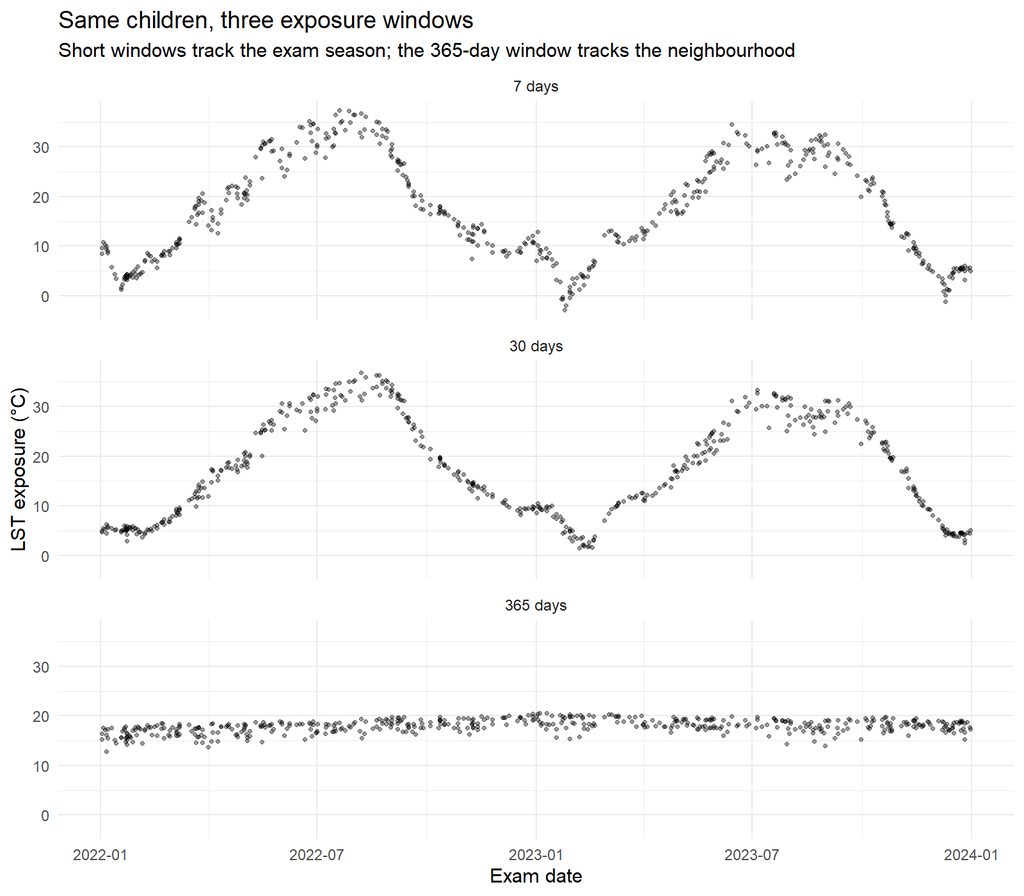

For a 7-day window, examination month explains 92% of variance in exposure and hexagon explains 1%. For a 365-day window this reverses: 63% is explained by hexagon. The 7- and 365-day exposures correlate at only 0.08, so for an individual child they are close to independent quantities.

This has direct design consequences. A short window answers questions about acute heat before assessment; a long window answers questions about the residential environment. Comparing children on an unadjusted 7-day exposure is largely comparing their appointment dates. Residual time dependence at 365 days (R² = 0.36) reflects genuine interannual variation, visible as the upward drift through 2022.

## 4.5 Equity gradient

Environmental exposure per 1 SD higher socioeconomic position

| outcome | per_1SD_higher_SES | CI_low | CI_high | p_clustered |
| --- | --- | --- | --- | --- |
| Annual LST (°C) | -0.2240 | -0.3280 | -0.1200 | 0e+00 |
| Green share, 300 m | 0.0355 | 0.0162 | 0.0549 | 3e-04 |
| NDVI, 300 m | 0.0262 | 0.0140 | 0.0384 | 0e+00 |
| Park >= 0.5 ha within 300 m (prob.) | 0.0231 | -0.0119 | 0.0581 | 2e-01 |

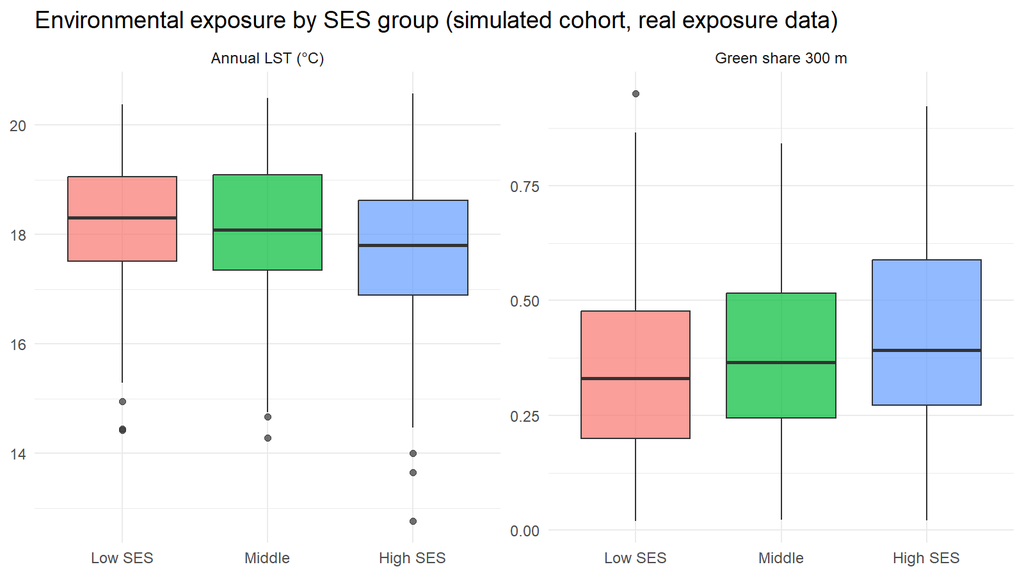

Standard errors are clustered by hexagon. Built-up share is a hexagon-level variable and the 500 children occupy 80 hexagons, so the number of independent spatial observations is far below the number of children. Models are deliberately unadjusted for built-up share and elevation: these are the pathways through which the inequality arises, and conditioning on them would remove the quantity of interest.

Per standard deviation of higher socioeconomic position, children experience **0.22 °C lower annual surface temperature**, **3.6 percentage points more green** within 300 m and **0.026 higher NDVI**. By tertile, the lowest group lives 0.4 °C warmer with 36% green nearby against 43% for the highest.

The informative null is park access. 88% of children have a public green space of at least 0.5 ha within 300 m, and this varies little by socioeconomic position (85–91%, p = 0.20). In this city inequality is not about the presence of a nearby green space but about how much greenery surrounds the home. An access-only indicator would have reported no inequality where a quantity-based indicator finds a clear gradient.

## 4.6 Recovery of a known parameter

Socioeconomic position was simulated with a specified dependence on built-up share, giving a true standardised slope of −0.447. The analysis was then asked to recover it.

Single-cohort recovery of the simulated parameter

| estimate | truth | SE_naive | SE_clust | CI_naive | CI_clust | truth_in_naive_CI | truth_in_clust_CI |
| --- | --- | --- | --- | --- | --- | --- | --- |
| -0.363 | -0.447 | 0.042 | 0.037 | -0.445 to -0.281 | -0.436 to -0.29 | FALSE | FALSE |

Replication over 500 simulated datasets

| truth | mean_estimate | coverage_naive | coverage_clust | pct_as_far_as_ours |
| --- | --- | --- | --- | --- |
| -0.447 | -0.447 | 98.6 | 97.6 | 0.6 |

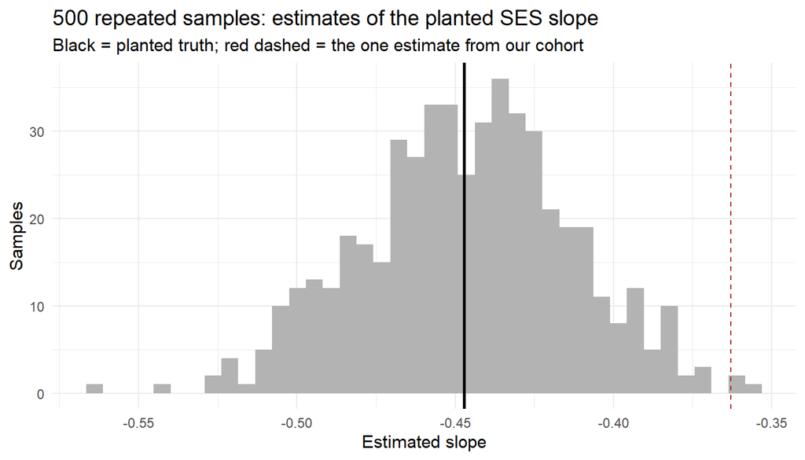

In the primary cohort the estimate was −0.363 with a clustered 95% interval of −0.436 to −0.290, which **excludes** the true value. Rather than reseed the simulation, the estimator was evaluated across 500 replications. The mean estimate was **−0.447**, identical to the planted value, and interval coverage was 98.6% (naive) and 97.6% (clustered) against a nominal 95%.

The estimator is therefore unbiased with slightly conservative intervals, and the primary cohort fell in the 0.6% tail of the sampling distribution. Clustering had little effect here because the simulated individual noise was independent within hexagons; with genuine neighbourhood-level correlation the correction would be substantial, and it is retained for that reason.

# 5 Database and maintenance

## 5.1 Structure

Tables in db/freiburg_exposure.duckdb

| Table | Rows |
| --- | --- |
| child | 500 |
| exposure_lst | 1500 |
| hexagon | 204 |
| lst_composite | 184 |
| lst_weekly | 37536 |
| outlier_log | 516 |
| run_log | 3 |

Seven tables under composite primary keys. `lst_weekly` is keyed on (hex_id, date), making a duplicate hexagon-week a constraint violation rather than a silent double count, and `lst_filled` is declared NOT NULL so a gap cannot be stored. Both constraints were verified by attempting the violation.

Every temperature row carries its `source` (observed, filled or removed outlier), the `method_version` that produced it and a `run_id` resolving to an entry in `run_log`. Any value in the database can be traced to the run that created it, and an analyst can restrict to observed values alone.

Provenance of every stored temperature value

| Year | Source | n |
| --- | --- | --- |
| 2021 | filled_clim_anomaly | 1268 |
| 2021 | observed | 7982 |
| 2021 | removed_outlier | 134 |
| 2022 | filled_clim_anomaly | 1689 |
| 2022 | observed | 7608 |
| 2022 | removed_outlier | 87 |
| 2023 | filled_clim_anomaly | 1104 |
| 2023 | observed | 8172 |
| 2023 | removed_outlier | 108 |
| 2024 | filled_clim_anomaly | 1478 |
| 2024 | observed | 7719 |
| 2024 | removed_outlier | 187 |

## 5.2 Incremental update

Pipeline run log

| run_id | run_type | period_start | period_end | n_lst_rows | description |
| --- | --- | --- | --- | --- | --- |
| 1 | initial build | 2021-01-01 | 2023-12-27 | 28152 | MODIS 2021-2023, gap-filling v1.1 (outlier screen + robust anomaly) |
| 2 | incremental update | 2024-01-01 | 2024-12-26 | 9384 | Added MODIS 2024 from staging; frozen v1.1 rules; earlier rows untouched |
| 3 | maintenance correction | NA | NA | 0 | Capped hexagon shares at [0,1]: floating-point excess < 1e-6 in inside_frac, found by automated test |

The 2024 composites were used to exercise the update path. New files land in a staging directory and pass a quality gate before ingestion: identical raster geometry (650 cells), dates on the 8-day calendar for their own year, and no date already present. Only then are hexagon means computed, the same 50% rule applied, and the **same outlier threshold reused** rather than re-estimated from the new data.

All inserts occur in a single transaction. The procedure is idempotent: re-running it reports that nothing is new rather than duplicating rows.

Incremental update, run 2

[output not shown]

## 5.3 Automated integrity tests

Nineteen assertions run against the database before and after any update: one row per hexagon-week; the grid complete against the composite inventory; no null filled values; only permitted source labels; observed values bit-identical to their raw inputs; every removed outlier present in the outlier log; every row resolving to a logged run; temperatures within −40 to 70 °C; land-cover shares within [0, 1]; 500 unique children each in a known hexagon; exactly three windows per child; and each year’s composite calendar starting 1 January in steps of 8 days.

The land-cover assertion failed on first execution, identifying 43 hexagons whose `inside_frac` exceeded 1 by floating-point rounding. The values were clamped in a logged transaction and the source file corrected so a rebuild does not reintroduce the defect.

# 6 Limitations

Known limitations and intended remedies

| Limitation | Consequence | Planned remedy |
| --- | --- | --- |
| Cohort is simulated | The socioeconomic gradient is partly by construction; the exposure data and the pipeline are real | Apply to real cohort data under a data-use agreement |
| Clear-sky sampling bias | Validation withheld clear weeks, so reported errors understate error in genuine cloud gaps | Introduce ERA5-Land reanalysis as a cloud-independent predictor |
| Fully missing composites | All methods converge near 3.7–4.0 °C; unusual weather in missing weeks is unrecoverable | Hybrid filling: anomaly where partial coverage exists, reanalysis-informed otherwise |
| Homes sampled uniformly on built-up land | Built-up cells include industrial and transport land, so a few homes fall in non-residential areas | Weight sampling by the Zensus 2022 100 m population grid |
| Spatial autocorrelation not modelled | Clustered standard errors address within-hexagon dependence but not continuous spatial correlation | Fit spatial error or CAR models as sensitivity analysis |
| Single-city, single-sensor | Thresholds tuned on Freiburg; transfer to flatter or larger cities requires re-validation | Replicate in a second city with contrasting terrain |
| External API stability | A Planetary Computer change to strict RFC3339 datetimes broke ingestion mid-project | Pin API contracts and assert response schema in the ingestion tests |

# 7 Reproducibility

Package versions are pinned with `renv`. Numbered scripts run in sequence from study-area definition through to the database update; downloads are cached so re-runs do not re-fetch. Random seeds are fixed, including the primary cohort seed, which was set before any result was examined and not subsequently changed.

Reproducibility summary

| Component | Value |
| --- | --- |
| R version | 4.5.1 |
| Database | DuckDB, 7 tables |
| Database size | 6.6 MB |
| Pipeline runs logged | 3 |
| Integrity tests | 19, all passing |
| Period covered | 01 Jan 2021 to 26 Dec 2024 |
| Figure files produced | 14 |
| Result table files | 9 |